# BIA-658 Lab 1 Exercises

Lokesh Mangireddygari

**Note**:

- Submit it as a HTML file (Knit to HTML) as HW1.
- Make sure you that the `Lab-1-Data/` folder is in the same directory of the Rmd file.

```r
#install.packages("tidyverse") #install packages before loading them if you haven't done so
#install.packages("igraph")
#install.packages("rlang")
#install.packages("ggplot2")
library(igraph)
library(tidyverse)
library(ggplot2)
```

Q1:  
Assign [100, -50, 20, -20, 40] to vector c1, [-214, -150, 10, -35, 10] to vector c2.  
Use the weekdays: [“Monday”, “Tuesday”, “Wednesday”, “Thursday”, “Friday”] to name both vectors.

Finally, add up the third element from c1 and second element from c2.

```r
# Write your code here
c1 <- c(100,-50,20,-20,40)
c2 <- c(-214, -150, 10, -35, 10)

weekdays <- c('Monday', 'Tuesday', 'Wednesday', 'Thursday', 'Friday')
names(c1) <- weekdays
names(c2) <- weekdays
c1
```

```
##    Monday   Tuesday Wednesday  Thursday    Friday
##       100       -50        20       -20        40
```

```r
c2
```

```
##    Monday   Tuesday Wednesday  Thursday    Friday
##      -214      -150        10       -35        10
```

```r
result<-c1[3]+c2[2]
result
```

```
## Wednesday
##      -130
```

Q2:  
Assign value [460, 300, 200, 470, 300, 160] to a vector c1. Use this vector to build a 3x2 matrix. The row name is [“A”, “B”, “C”], the col name is [“D”, “E”].

Next step, get the sum of each col, name it as “Sum_col”, as well as the sum of each row, called “Sum_row”. Then, bind the new row and col to the original matrix.

Finally, select out the element at 4th row and 3nd col in this new matrix.

```r
# Write your code here
#Assign  the values to the vector (VectorC1)
vectorC <- c(460, 300, 200, 470, 300, 160)
#build a 3x2 matrix
Lab1 <- matrix (vectorC, nrow = 3, ncol =2)
Lab1
```

```
##      [,1] [,2]
## [1,]  460  470
## [2,]  300  300
## [3,]  200  160
```

```r
#Assign the row names and column names to the 3x2 matrix
rownames(Lab1) <- c("A", "B", "C")
colnames(Lab1) <- c("D", "E")
Lab1
```

```
##     D   E
## A 460 470
## B 300 300
## C 200 160
```

```r
#Sum of Rows
Sum_row <- rowSums(Lab1)
Lab1 <-cbind(Lab1, Sum_row)
Lab1
```

```
##     D   E Sum_row
## A 460 470     930
## B 300 300     600
## C 200 160     360
```

```r
Sum_Col <- colSums(Lab1)
Lab1 <-rbind(Lab1, Sum_Col)
Lab1
```

```
##           D   E Sum_row
## A       460 470     930
## B       300 300     600
## C       200 160     360
## Sum_Col 960 930    1890
```

```r
Lab1[4,3]
```

```
## [1] 1890
```

Q3:  
Write a function definition for fun_1().

- One input argument, num_views
- If num_views is greater than 15, the function prints out “Nice job” and returns num_views.
- Otherwise, the function prints out “Bad for you” and returns 0.
- Finally, call the function and apply it on the following vector: (16, 19, 3, 25, 12, 17, 4)

```r
# Write your code here
fun_1 <- function(num_views) {
 if(num_views>15){
 print("nicejob")
 return(num_views)
 }
 else {
 print("bad for you")
 return(0)
 }
}

for (a in c(16,19,3,25,12,17,4)) {
 fun_1(a)
}
```

```
## [1] "nicejob"
## [1] "nicejob"
## [1] "bad for you"
## [1] "nicejob"
## [1] "bad for you"
## [1] "nicejob"
## [1] "bad for you"
```

Q4:

The FizzBuzz test is a popular test that companies use to screen applicants who claim they can code. A surprising number of applicants (some claim 99%) would fail the test.

Write a program in R that prints the numbers from 1 to 100. But for multiples of three print “Fizz” instead of the number and for the multiples of five print “Buzz”. For numbers which are multiples of both three and five print “FizzBuzz”. The output should look like

[1] 1  
[1] 2  
[1] “Fizz”  
[1] 4  
[1] “Buzz”  
[1] “Fizz”  
[1] 7  
[1] 8  
[1] “Fizz”  
[1] “Buzz”  
[1] 11  
[1] “Fizz”  
[1] 13  
[1] 14  
[1] “FizzBuzz”  
[1] 16

Hint: use %% to check divisibility, e.g., x%%5 == 0 means x is divisible by 5

```r
# Write your code here
for (a in 1:100) {
 if(a %% 15 == 0){
 print("Fizz Buzz")
 }
 else if(a %% 3 == 0){
 print("Buzz")
 }
 else if(a %% 5 == 0){
 print("Fizz")
 }
 else{
 print(a)
 }
}
```

```
## [1] 1
## [1] 2
## [1] "Buzz"
## [1] 4
## [1] "Fizz"
## [1] "Buzz"
## [1] 7
## [1] 8
## [1] "Buzz"
## [1] "Fizz"
## [1] 11
## [1] "Buzz"
## [1] 13
## [1] 14
## [1] "Fizz Buzz"
```

[output cut: 85 more lines]

Q5:  
Here is your first challenge of Tidyverse. Load the `MarathonData.csv` dataset. Remember the three function we just introduced? Time to apply them on this new set! - select all the observations whose Category is M40 - find the median value of Marathon time and maximum value of km4week within each class, saving them into medianTime and maxWeeks, respectively - sort in descending order by that maxWeeks - create a bar plot to show the median Marathon time by class

```r
MarathonData <- read.csv("/Users/lokeshreddy/Downloads/Social Networks/Lab-1-Data/MarathonData.csv")
#make sure the dataset is in your working directory
# Write your code here
subset(MarathonData,Category == 'M40')
```

```
##    id Marathon                    Name Category km4week   sp4week CrossTraining
## 6   6 Prague17            David Pecina      M40    42.2 13.612903
## 7   7 Prague17            Tomas Drabek      M40    89.0 12.594340
## 14 14 Prague17             Ji?، Polcar      M40    84.4 13.836066
## 18 18 Prague17             David Marek      M40    49.7 14.336538
## 22 22 Prague17           Jind?ich Lisى      M40    67.3 13.239344
## 23 23 Prague17 Carlos Valladares Calvo      M40    59.4 12.638298
## 45 45 Prague17        Dalibor Sma?inka      M40    27.7 11.622378   ciclista 3h
## 53 53 Prague17           Luk ? Charv t      M40   121.7  9.907734
## 55 55 Prague17             ????? ?????      M40    70.7 11.783333
## 60 60 Prague17      Hannes Lilljequist      M40    45.2 11.024390
## 61 61 Prague17        Szigyarto Laszlo      M40    43.2 10.936709
## 65 65 Prague17     Frederic Bonningues      M40    54.2 11.782609
## 84 84 Prague17          Andrej Madliak      M40    33.6 10.130653   ciclista 3h
## 85 85 Prague17              Yoi Ohsako      M40    55.4 11.043189
```

[output cut: 17 more lines]

```r
challenge1 <- MarathonData %>%
              group_by(Class) %>%
              summarise(maxWeeks = max(km4week),medianTime = median(MarathonTime))
challenge1
```

```
## # A tibble: 4 × 3
##   Class maxWeeks medianTime
##   <chr>    <dbl>      <dbl>
## 1 A         138.       2.87
## 2 B         130.       3.22
## 3 C         122.       3.52
## 4 D          87        3.89
```

```r
challenge2 <- challenge1 %>%
                   arrange(desc(maxWeeks))
challenge2
```

```
## # A tibble: 4 × 3
##   Class maxWeeks medianTime
##   <chr>    <dbl>      <dbl>
## 1 A         138.       2.87
## 2 B         130.       3.22
## 3 C         122.       3.52
## 4 D          87        3.89
```

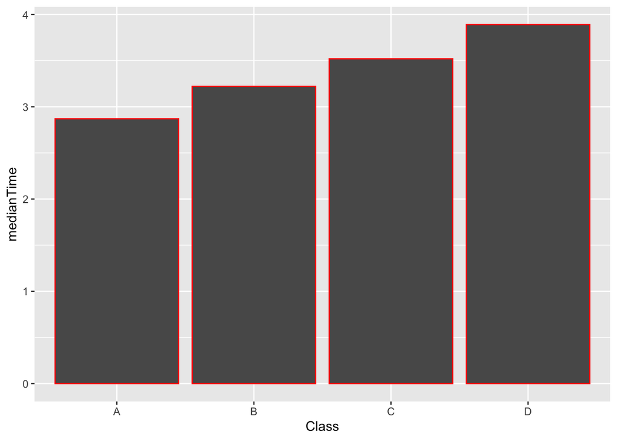

```r
#BAR PLOT used GGPLOT
ggplot(challenge1, aes(x=Class, y=medianTime)) + geom_col(color = 'red')
```

Q6:Explore the organizational collaboration network. The network information is stored in Org.csv.

Tasks: -Create a graph object from the csv file. – Specify if the edges are directed or undirected (make a judgement yourself). – Name the nodes with column/row names -Plot the network, with the circle layout, node size as 10 and node label as blue -Find the diameter of the network (include both your code and result) -Find the longest path in the network (include both code and result)

```r
# Write your code here
OrgDataLoad <- read.csv("/Users/lokeshreddy/Downloads/Social Networks/Lab-1-Data/Org.csv")
GraphObject <- graph.data.frame(OrgDataLoad, directed = TRUE)
GraphObject
```

```
## IGRAPH 1457ad0 DN-- 18 17 --
## + attr: name (v/c), Org2 (e/n), Org3 (e/n), Org4 (e/n), Org5 (e/n),
## | Org6 (e/n), Org7 (e/n), Org8 (e/n), Org9 (e/n), Org10 (e/n), Org11
## | (e/n), Org12 (e/n), Org13 (e/n), Org14 (e/n), Org15 (e/n), Org16
## | (e/n), Org17 (e/n)
## + edges from 1457ad0 (vertex names):
##  [1] Org1 ->0 Org2 ->0 Org3 ->0 Org4 ->0 Org5 ->0 Org6 ->0 Org7 ->0 Org8 ->0
##  [9] Org9 ->0 Org10->0 Org11->0 Org12->0 Org13->0 Org14->0 Org15->0 Org16->0
## [17] Org17->0
```

```r
OrgDataLoadMatrix <- as.matrix(OrgDataLoad[-2])
OrgDataLoadMatrix #As I Observe Since The MAtrix Looks asymmentric as per my knowledge, i guess this is directed
```

```
##       X       Org2 Org3 Org4 Org5 Org6 Org7 Org8 Org9 Org10 Org11 Org12 Org13
##  [1,] "Org1"  "0"  "0"  "0"  "0"  "1"  "0"  "0"  "1"  "0"   "0"   "0"   "0"
##  [2,] "Org2"  "0"  "0"  "0"  "0"  "1"  "0"  "0"  "1"  "0"   "1"   "0"   "0"
##  [3,] "Org3"  "0"  "0"  "0"  "1"  "1"  "0"  "0"  "1"  "0"   "0"   "0"   "0"
##  [4,] "Org4"  "0"  "0"  "0"  "1"  "1"  "0"  "0"  "1"  "0"   "0"   "0"   "0"
##  [5,] "Org5"  "0"  "0"  "0"  "0"  "1"  "0"  "0"  "1"  "0"   "0"   "0"   "0"
##  [6,] "Org6"  "0"  "0"  "0"  "1"  "0"  "0"  "0"  "1"  "0"   "0"   "0"   "0"
##  [7,] "Org7"  "0"  "0"  "0"  "0"  "0"  "0"  "0"  "0"  "0"   "0"   "0"   "0"
##  [8,] "Org8"  "0"  "0"  "0"  "0"  "0"  "0"  "0"  "0"  "0"   "0"   "0"   "0"
##  [9,] "Org9"  "0"  "0"  "0"  "0"  "0"  "0"  "0"  "0"  "0"   "0"   "0"   "0"
## [10,] "Org10" "0"  "0"  "0"  "0"  "0"  "0"  "0"  "0"  "0"   "1"   "0"   "0"
## [11,] "Org11" "0"  "0"  "0"  "0"  "0"  "0"  "0"  "0"  "0"   "0"   "1"   "0"
## [12,] "Org12" "0"  "0"  "0"  "0"  "0"  "0"  "1"  "0"  "0"   "1"   "0"   "0"
## [13,] "Org13" "0"  "0"  "0"  "0"  "1"  "0"  "0"  "1"  "0"   "0"   "0"   "0"
## [14,] "Org14" "0"  "0"  "1"  "0"  "1"  "0"  "0"  "1"  "0"   "0"   "0"   "0"
```

[output cut: 21 more lines]

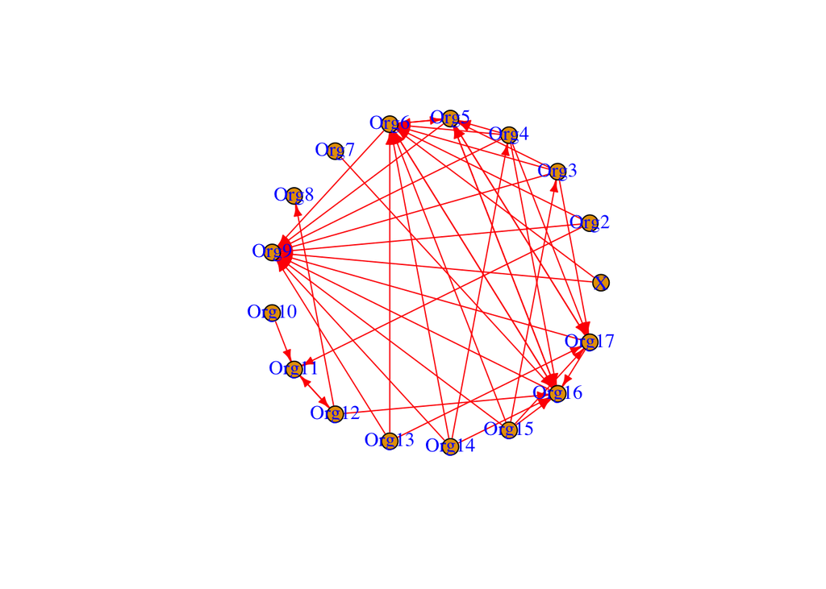

```r
row.names(OrgDataLoadMatrix)<-colnames(OrgDataLoadMatrix)
Network<-graph_from_adjacency_matrix(OrgDataLoadMatrix, mode= "directed")
#PLOT
plot(Network,edge.color="red",edge.width=E(Network)$weight,layout=layout.circle,edge.arrow.size=0.5,vertex.size=10, vertex.label.color="blue")
```

```r
#DIAMETER
diameter(Network,directed=TRUE)
```

```
## [1] 5
```

```r
#LONGESTPATH
get_diameter(Network,directed=TRUE)
```

```
## + 6/17 vertices, named, from b67d1e5:
## [1] Org10 Org11 Org12 Org16 Org5  Org17
```

Q7:Explore CEO personal networks The edges are stored in CEOs-EDGES.csv. The network is undirected and weighted. Node attributes are stored in CEOs-ARRT.csv. The attributes include node names, gender and whether the company is a Fortune500 company.

Tasks: -Create a graph object from the network edges. -Add node attributes: node names, gender the nodes with the column/role names. -Add edge attributes: edge weight -Plot the network, with node colors indicating gender, node shape indicating whether the company is a Fortune500 and edge with showing edge weights -Answer in one sentence: What can you tell about the network?

```r
# Write your code here
#LOAD DATA
EdgesData <- read.csv("/Users/lokeshreddy/Downloads/Social Networks/Lab-1-Data/CEOs-EDGES.csv")
EdgesData
```

```
##    Node1 Node2 ID Weight
## 1      1     5  1      2
## 2      1     7  2      8
## 3      1    12  3      3
## 4      1    14  4      4
## 5      2    16  5      5
## 6      2    17  6      6
## 7      2    18  7      7
## 8      3     5  8      3
## 9      3     7  9      5
## 10     4     6 10      2
## 11     4     7 11      3
## 12     4     8 12      3
## 13     5     6 13      1
## 14     5     7 14      2
```

[output cut: 25 more lines]

```r
ArrtData <- read.csv("/Users/lokeshreddy/Downloads/Social Networks/Lab-1-Data/CEOs-ARRT.csv")
ArrtData
```

```
##      Node Gender Fortune.500
## 1   CEO-1      F           0
## 2   CEO-2      M           1
## 3   CEO-3      M           0
## 4   CEO-4      M           0
## 5   CEO-5      M           0
## 6   CEO-6      M           0
## 7   CEO-7      F           0
## 8   CEO-8      M           0
## 9   CEO-9      M           1
## 10 CEO-10      M           0
## 11 CEO-11      M           0
## 12 CEO-12      M           0
## 13 CEO-13      M           0
## 14 CEO-14      M           0
## 15 CEO-15      F           1
## 16 CEO-16      M           1
## 17 CEO-17      M           1
## 18 CEO-18      M           1
```

```r
GraphObjectA <- graph.data.frame(EdgesData, directed = FALSE)
GraphObjectA
```

```
## IGRAPH f73e440 UN-- 18 39 --
## + attr: name (v/c), ID (e/n), Weight (e/n)
## + edges from f73e440 (vertex names):
##  [1] 1 --5  1 --7  1 --12 1 --14 2 --16 2 --17 2 --18 3 --5  3 --7  4 --6
## [11] 4 --7  4 --8  5 --6  5 --7  6 --8  7 --8  7 --13 9 --10 9 --12 9 --14
## [21] 9 --15 9 --16 9 --17 9 --18 10--12 10--14 11--16 11--17 12--14 13--15
## [31] 13--18 15--18 15--16 11--16 16--17 16--18 11--17 16--17 17--18
```

```r
V(GraphObjectA)$name <- c(ArrtData$Node)
GraphObjectA <- set_vertex_attr(GraphObjectA,'Fortune.500',index=V(GraphObjectA)$name,ArrtData$Fortune.500)
get.vertex.attribute(GraphObjectA,'Fortune.500')
```

```
##  [1] 0 1 0 0 0 0 0 0 1 0 0 0 0 0 1 1 1 1
```

```r
GraphObjectA <- set_vertex_attr(GraphObjectA,'gender',index=V(GraphObjectA)$name,ArrtData$Gender)
get.vertex.attribute(GraphObjectA, 'gender')
```

```
##  [1] "F" "M" "M" "M" "M" "M" "F" "M" "M" "M" "M" "M" "M" "M" "F" "M" "M" "M"
```

```r
GraphObjectA <- set_edge_attr(GraphObjectA,'Weight',index=E(GraphObjectA),EdgesData$Weight)
get.edge.attribute(GraphObjectA,'Weight')
```

```
##  [1] 2 8 3 4 5 6 7 3 5 2 3 3 1 2 5 2 2 2 3 1 5 6 7 5 1 2 5 6 3 2 3 5 4 5 5 5 3 6
## [39] 6
```

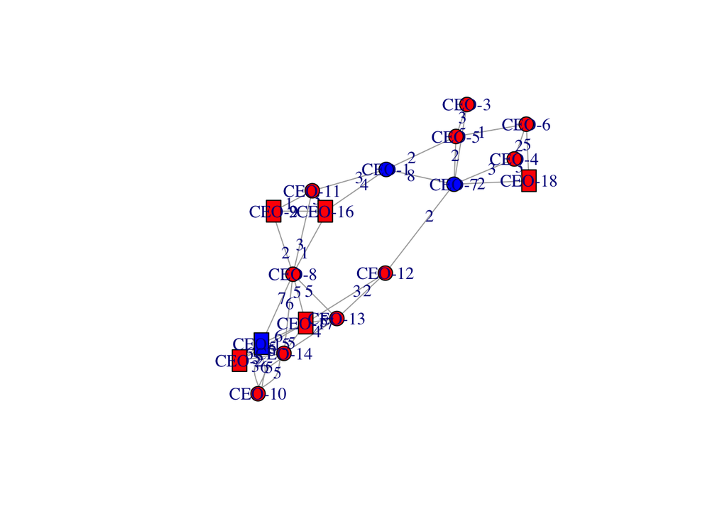

```r
#FORTUNE500 OR NOT
V(GraphObjectA)$shape=V(GraphObjectA)$Fortune.500
#FORTUNE500
V(GraphObjectA)$shape=gsub(1,"rectangle",V(GraphObjectA)$shape)
#NOTFORTUNE500
V(GraphObjectA)$shape=gsub(0,"circle",V(GraphObjectA)$shape)
#Gender: M:Male or F:Female
V(GraphObjectA)$color=V(GraphObjectA)$gender
#MALE
V(GraphObjectA)$color=gsub("M","red",V(GraphObjectA)$color)
#FEMALE
V(GraphObjectA)$color=gsub("F","blue",V(GraphObjectA)$color)
#PLOT
plot(GraphObjectA, layout=layout.fruchterman.reingold,vertex.label= V(GraphObjectA)$Node,vertices.shape=V(GraphObjectA)$shape,vertices.color=V(GraphObjectA)$color,  edge.arrow.size=0.5,vertex.size=10,edge.label=EdgesData$Weight)
```

```r
#Its More like distributed Network as of my knowledge and I dont think its centralized since there are many connections to join all the fortune 500 companies like ceo-12, ceo-8 and ceo-1.
```